# US foreign aid since 1980

Samal Abdikerimova, Ravi Donepudi, Carlos Salinas, and Xiran Yu

/05/06/2020/

Here are some thoughts regarding this mini-project. We will use the data in `aiddata-countries-only.csv` to figure out how much funding there has been to foreign countries since 1980. We would like how much the total funding for projects per year has changed over time.

Here we will import the date and filter out any entries before 1980.

```r
df <- read.csv("1_Data/aiddata-countries-only.csv")
df2 <- df %>% filter(2020 > year & year >= 1980)
```

```r
df_usa <- df2 %>%
    group_by(year) %>%
    filter(donor == "United States")
```

The following plot shows the aid the United States has given to foreign countries since 1980.

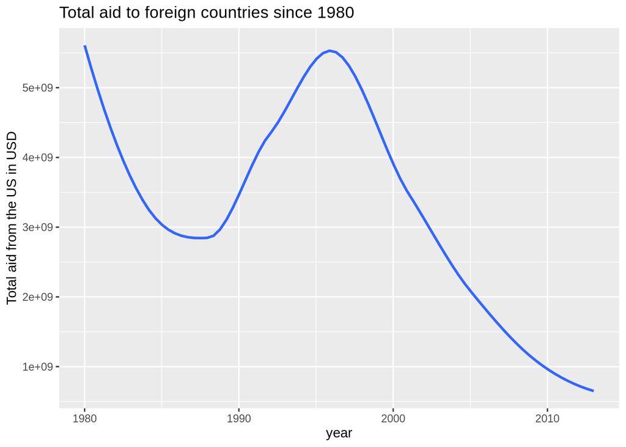

```r
df_usa %>%
    group_by(year) %>%
    filter(commitment_amount_usd_constant > (5 * 10 ^6)) %>%
    summarize(total_aid = sum(commitment_amount_usd_constant)) %>%
    ungroup() %>%
    ggplot() +
    geom_smooth(se=FALSE, mapping = aes(x = year, y = total_aid)) +
    labs(title="Total aid to foreign countries since 1980",
         y="Total aid from the US in USD")
```

Next we focus on the top 10 countries to receive the most aid from the United States. We do this by running the following commands.

```r
top_countries <- df_usa %>%
    group_by(recipient) %>%
    summarize(total_aid = sum(commitment_amount_usd_constant)) %>%
    arrange(desc(total_aid)) %>%
    slice(1:10)
countries <- top_countries$recipient
```

If we plot the top 10 countries we see that there are two notable spikes one in the early 1990s for Kuwait and one in the late 1990s for Saudi Arabia. This is due to the Iranian Gulf War for the former and the 1998 Saudi Arabian War.

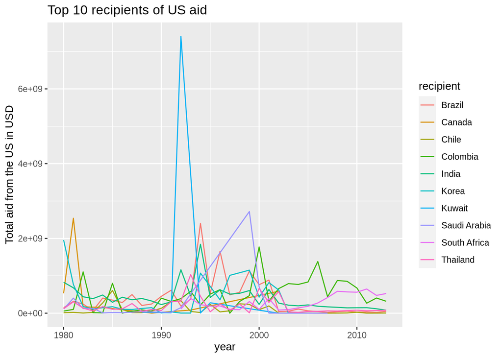

```r
df_usa %>%
    filter(recipient %in% countries) %>%
    group_by(year,recipient) %>%
    summarize(total_aid = sum(commitment_amount_usd_constant)) %>%
    ungroup() %>%
    ggplot(aes(x = year, y = total_aid, color = recipient)) +
    geom_line() +
    labs(title="Top 10 recipients of US aid",
         y="Total aid from the US in USD")
```

Why are we donating so much to Kuwait and Saudi Arabia in the 90s? Let’s find out.